# Comparing adverse events between countries by exploring the OpenFDA data

Jonathan Stott

This document starts with some exploration of the data, then looks into the country question in more detail…

Data were extracted from the [OpenFDA adverse events](https://open.fda.gov/drug/event/) using `fetch_2015.R`. This extracts a subset of the data which was recieved in 2015.

```r
reports <- read_csv('data/fda/raw/2015_reports.csv', col_types = cols(
  reportid = col_character(),
  primarysource = readr::col_factor(levels = c("Physician", "Pharmacist","Other health professional", "Lawyer", "Consumer or non-health professional", "Unknown")),
  patientage = col_integer(),
  patientageunit = readr::col_factor(levels = c("Decade", "Year", "Month", "Week", "Day", "Hour")),
  patientsex = readr::col_factor(c("Unknown", "Male", "Female")),
  country = readr::col_factor(levels = NULL),
  transmission_date = col_date("%Y-%m-%d"),
  receipt_date = col_date("%Y-%m-%d")
)
) %>% mutate(
  country = fct_infreq(country)
)

drugs   <- read_csv('data/fda/raw/2015_drugs.csv', col_types = cols(
  reportid = col_character(),
  Drug = col_character(),
  Indication = col_character()
))
reacts  <- read_csv('data/fda/raw/2015_reacts.csv', col_types = cols(
  reportid = col_character(),
  React = col_character()
))
```

There are 290313 in the dataset, which represents 10233 types of adverse event, from 33440 drugs.

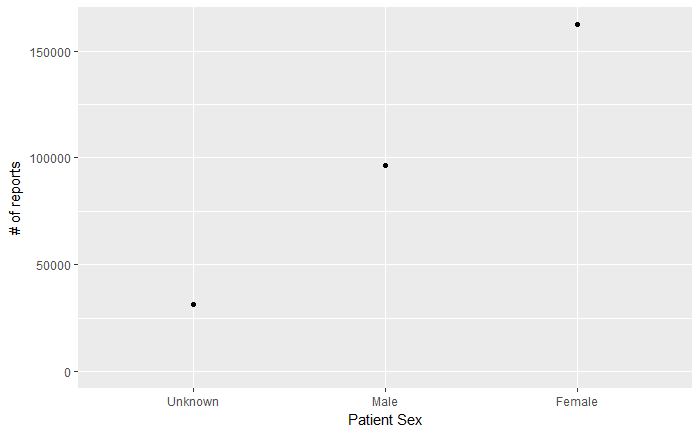

```r
reports %>% count(patientsex) %>% arrange(-n) %>% ggplot(aes(x = patientsex, y = n)) +
  geom_point() + labs(y = "# of reports", x = "Patient Sex") + expand_limits(y = 0)
```

## Differences by country

```r
reports_per_country <- reports %>% count(country) %>% arrange(-n)
reports_per_country %>% head(10)
```

| country | n |
| --- | --- |
| US | 204133 |
| GB | 16617 |
| JP | 8609 |
| CA | 7966 |
| DE | 6610 |
| FR | 6339 |
| IT | 5193 |
| BR | 3912 |
| NL | 2829 |
| AU | 2421 |

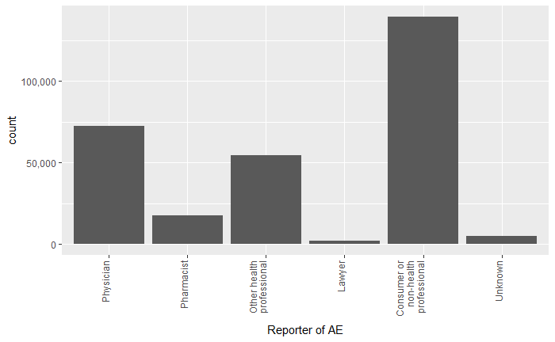

```r
reports %>% ggplot(aes(x = primarysource)) + geom_bar() + labs(x = 'Reporter of AE', y = 'count') + scale_y_continuous(labels = comma) + theme(axis.text.x = element_text(angle = 90, hjust = 1, vjust = 0)) +
   scale_x_discrete(labels = function(x) stringr::str_wrap(x, width = 15))
```

Most events are reported by the consumer themselves, followed by physians and then other healthcare professionsals. Could be interesting to look at this over time and see how that changed (if at all). Very few lawyers are involved in the process it seems.

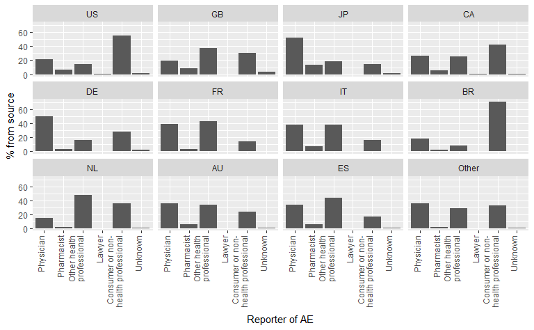

```r
# do this long-hand as there doesn't seem to be a nice ggplot option to scale the output weel
country_subset <- reports %>%
  mutate(country = fct_lump(country, n = 11)) %>%
  filter(!is.na(country)) # this only represents 168 events
events_per_country <- country_subset %>% group_by(country) %>% count() %>% rename(total_per_country = n)
country_subset %>%
  group_by(country, primarysource) %>%
  count() %>%
  left_join(events_per_country, by = 'country') %>%
  mutate(n = n/total_per_country) %>%
  ggplot(aes(x = primarysource, y = n*100)) + geom_bar(stat= 'identity') + labs(x = 'Reporter of AE', y = '% from source') + scale_y_continuous(labels = comma) + theme(axis.text.x = element_text(angle = 90, hjust = 1, vjust = 0)) +
   scale_x_discrete(labels = function(x) stringr::str_wrap(x, width = 20)) + facet_wrap(~country)
```

Unsuprisingly, the US shows the same shape as the overall picture. The already very rare laywers don’t seem to feature at all in reports outside the US. Canada has a similar picture to the US, though more balanced between Health professionals and consumer reports. Brazil is skewed the other way, with most reports coming from non-health professionals. Japan and Germany show a relatively strong lean toward physicians. Generally the rest of the world seems to have a lean toward events being reported from healthcare professionals – is this a reflection of how things are reported, or are healthcare professional reports more likely to be cascaded to the FDA?

## Adverse Events distribution

Top 10 adverse events per report

```r
reaction_counts <- reacts %>% unique() %>% count(React) %>% arrange(-n)
reaction_counts %>% head(10)
```

| React | n |
| --- | --- |
| Drug ineffective | 17919 |
| Death | 13435 |
| Nausea | 10871 |
| Fatigue | 10601 |
| Headache | 9662 |
| Pain | 8974 |
| Diarrhoea | 8493 |
| Malaise | 8296 |
| Dyspnoea | 7928 |
| Off label use | 7696 |

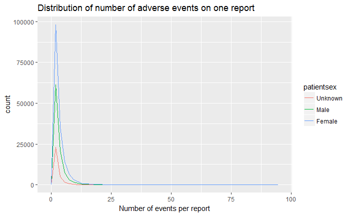

```r
reports %>% left_join(reacts %>% unique %>% count(reportid)) %>% ggplot(aes(x = n, colour = patientsex)) + geom_freqpoly(bins = 50) + labs(x = "Number of events per report", title = "Distribution of number of adverse events on one report")
```

## drugs distribution

Top 10 drugs per report, treating multiple occurences on one report as 1 appearance

```r
drugs %>% select(reportid, Drug) %>% unique() %>% count(Drug) %>% arrange(-n) %>% head(10)
```

| Drug | n |
| --- | --- |
| ENBREL | 34280 |
| HUMIRA | 8730 |
| TECFIDERA | 7693 |
| XARELTO | 6772 |
| ASPIRIN. | 6393 |
| METHOTREXATE | 6302 |
| PREDNISONE. | 6087 |
| METFORMIN | 5940 |
| AVONEX | 5609 |
| PEGASYS | 5331 |

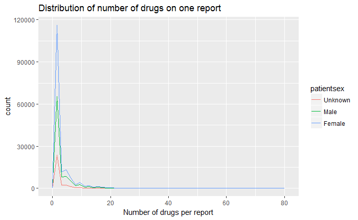

```r
reports %>% left_join(drugs %>% select(reportid,Drug) %>% unique %>% count(reportid)) %>% ggplot(aes(x = n, colour = patientsex)) + geom_freqpoly(bins = 50) + labs(x = "Number of drugs per report", title = "Distribution of number of drugs on one report")
```

The vast bulk of reports have one or two drugs involved.

There’s no obvious relationship between number of reported reactions and the number of drugs taken

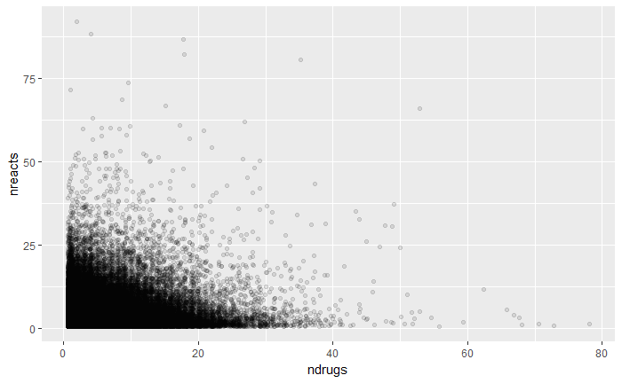

```r
reports %>%
  left_join(reacts %>% unique %>% count(reportid) %>% rename(nreacts = n)) %>%
  left_join(drugs %>% select(reportid,Drug) %>% unique %>% count(reportid) %>% rename(ndrugs = n)) -> annotated_reports
ggplot(annotated_reports, aes(x = ndrugs, y = nreacts)) + geom_jitter(alpha = 0.1)
```

## By Age

Distribution of reports by patient age

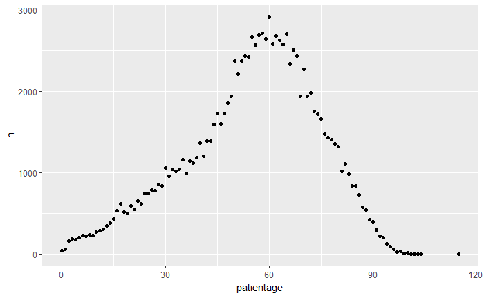

```r
reports %>% filter(patientageunit == 'Year', !is.na(patientage)) %>% count(patientage) %>% ggplot(aes(x = patientage, y = n)) + geom_point()
```

# Differences per country deeper dive

Can we pick up on any differences on a country level in the types of events reported?

## Hierachical Clustering

Try to arrange the countries into groups based on their ‘adverse event signature’, which are the proportions of their adverse event reports which mention a particular common (occurs in >=1% of all reports) adverse event. Only countries with at least 500 individual reports are considered.

```r
common_reactions <- reaction_counts %>%
  filter(n >= nrow(reports)*0.01) %>% # reactions that occur in at least 1% of reports
  semi_join(reacts, ., by = 'React') # select only those reactions
reports_with_reactions <- reports %>%
  inner_join(common_reactions %>% unique(), by = 'reportid')
reports_per_country_subset <- reports_with_reactions %>% count(country) %>% rename(n_per_country = n)
# construct the report signature for each country
report_signature <- reports_with_reactions %>%
  select(reportid, country, React) %>%
  left_join(reports_per_country_subset, by = 'country') %>%
  filter(n_per_country >= 500) %>% # pick only countries with at least 500 reports
  mutate(value = 1) %>%
  spread(React, value, fill = 0) %>%
  select(-reportid, -n_per_country) %>%
  group_by(country) %>%
  summarise_all(sum) %>%
  left_join(reports_per_country_subset, by = 'country') %>%
  mutate_if(is.double, funs(. / n_per_country)) %>%
  select(-n_per_country)
```

Use the canberra distance metric, as we’re dealing with (normalised) counts. Use the clustering method due to Ward to cluster together to try and get small clusters.

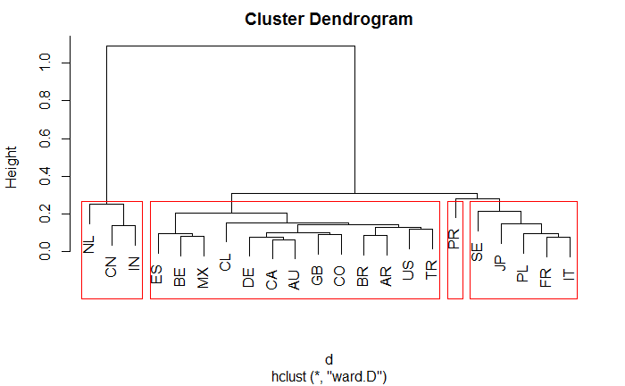

```r
report_matrix <- report_signature %>% select(-country) %>% as.matrix()
rownames(report_matrix) <- report_signature %>% select(country) %>% unlist()
d <- dist(report_matrix, d = 'can')
hc <- hclust(d, method ='ward.D')
plot(hc)
nGroup <- 4
groups <- cutree(hc, k=nGroup) # cut tree into 5 clusters
rect.hclust(hc, k=nGroup, border="red")
```

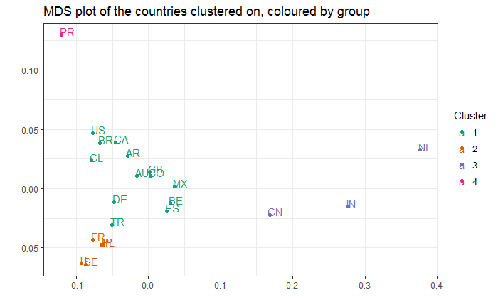

```r
md <- cmdscale(d) %>%
  as.data.frame() %>%
  rownames_to_column(var = 'country') %>%
  mutate(group = groups)
ggplot(md, aes(x = V1, y = V2, colour = as.factor(group))) + geom_point() + geom_text(aes(label = country), hjust = 0.1, vjust = 0.1) + scale_color_brewer(palette = 'Dark2') + theme_bw() + labs(x = '', y = '', colour = 'Cluster', title = "MDS plot of the countries clustered on, coloured by group")
```

## PCA

To try and understand some of the clustering, try PCA to see how the report signature is distributed over the countries.

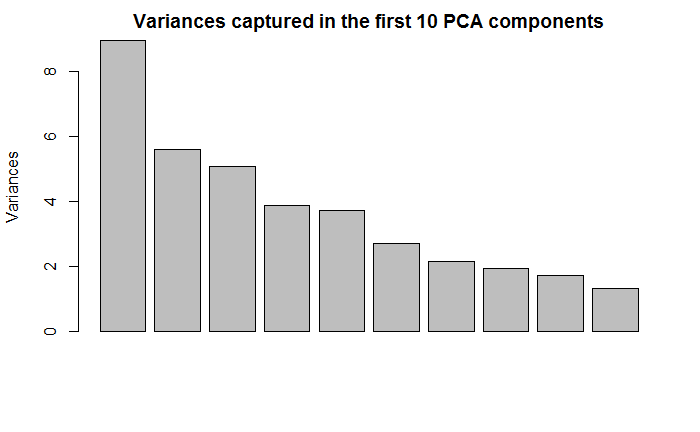

```r
pca <- prcomp(report_matrix, center = T, scale. = T)
plot(pca, main = "Variances captured in the first 10 PCA components")
```

### Biplot

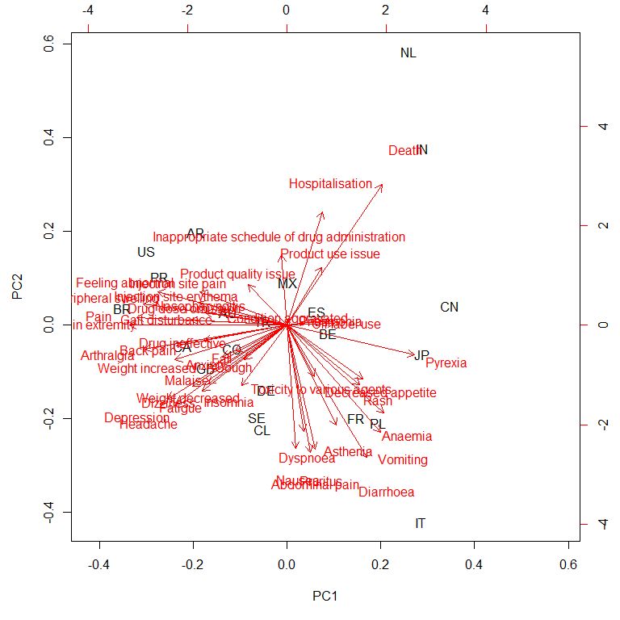

```r
biplot(pca)
```

Biplot suggests that IN, NL (and perhaps CN) share a cluster (3) in the hierachical clustering due to an increased proportion of reported deaths. Cluster 2, with Italy and France, seems to be driven by a lot of gastrointenstinal events such as vomiting nad diarrhoea. The largest cluster, 1, which includes the US seems to have a diversity of events reported. From the biplot, it’s not clear why Pueto Rico (PR) is clustered on its own (or from the denogram, with France, Italy et al), though the PCA wasn’t used for clustering.

## Conclusions

This initial analysis points at differences in both who reports, and what events, are reported to the FDA between countries. There’s obviously a very large bias in the data set toward the US. It’s not clear if there’s a reporting bias, with only more serious overseas events making their way back to the FDA. It would be interesting to compare this to similar data from the UK (or other national health agencies).